# California Housing Prices K-Means Clustering Analysis

**Jasmine Jordan-Lake and Zoe Severson**

## Introduction:

The California housing market is representative of a dynamic market influenced by several factors such as housing prices, household income, and geographical diversity. During this analysis, we will utilize a [California Housing Prices Dataset](https://www.kaggle.com/datasets/camnugent/california-housing-prices/data) to examine and visualize patterns, correlations, and potential trends. This dataset provides a comprehensive view of housing attributes across different regions in California, offering insights into geographical variations in housing prices and other related factors.

**Objectives:**

1. Ensure data accuracy and reliability by fixing errors, inconsistencies, and missing values.
2. Utilize K-means clustering to identify distinct clusters within the California housing market based on geographical coordinates and median income.
3. Visualize and interpret the identified clusters based on their demographics, primarily looking at median income, housing median age, median house value, and ocean proximity.
4. Extract actionable insights from the clustering results to inform strategic decisions in areas such as real estate investment, urban planning, and economic development.

# Import Necessary Libraries And Read In Dataset

In this section, we will initialize our Jupyter Notebook by importing essential libraries necessary for data visualization, manipulation, and clustering analysis. After importing these libraries, we will read in our dataset, using Pandas' read_csv() function. This action loads the dataset into a Pandas DataFrame named 'df', allowing us to access its contents for data cleaning, transformation, and analysis tasks. This setup equips us with the necessary tools to efficiently explore, analyze, and visualize the dataset, laying the groundwork for future data processing and clustering tasks.

```python
import pandas as pd
import numpy as np
import matplotlib.pyplot as plt
from sklearn.cluster import KMeans
import seaborn as sns
```

```python
df = pd.read_csv("housing.csv")
```

The DataFrame will be named 'df' for future purposes.

# Perform Initial Exploration

During this section, we begin by performing an initial exploration of the dataset. We can start by examining the first few rows of the DataFrame using df.head() to get a glimpse of the data's structure. Following that, we use df.shape to understand the dimensions of our dataset. Additionally, we will utilize df.describe() to obtain statistical summaries such as mean, standard deviation, and quartile information for numerical columns, giving us insights into the distribution of our data. Lastly, we create a scatter plot of latitude and longitude coordinates to visualize geographical distribution to help enhance our understanding of the dataset's spatial characteristics.

```python
df.head()
```

|  | longitude | latitude | housing_median_age | total_rooms | total_bedrooms | population | households | median_income | median_house_value | ocean_proximity |
| --- | --- | --- | --- | --- | --- | --- | --- | --- | --- | --- |
| 0 | -122.23 | 37.88 | 41.0 | 880.0 | 129.0 | 322.0 | 126.0 | 8.3252 | 452600.0 | NEAR BAY |
| 1 | -122.22 | 37.86 | 21.0 | 7099.0 | 1106.0 | 2401.0 | 1138.0 | 8.3014 | 358500.0 | NEAR BAY |
| 2 | -122.24 | 37.85 | 52.0 | 1467.0 | 190.0 | 496.0 | 177.0 | 7.2574 | 352100.0 | NEAR BAY |
| 3 | -122.25 | 37.85 | 52.0 | 1274.0 | 235.0 | 558.0 | 219.0 | 5.6431 | 341300.0 | NEAR BAY |
| 4 | -122.25 | 37.85 | 52.0 | 1627.0 | 280.0 | 565.0 | 259.0 | 3.8462 | 342200.0 | NEAR BAY |

```python
df.shape
```

```
(20640, 10)
```

From df.shape, we see that there are 20,640 observations and 10 features.

```python
df.describe()
```

|  | longitude | latitude | housing_median_age | total_rooms | total_bedrooms | population | households | median_income | median_house_value |
| --- | --- | --- | --- | --- | --- | --- | --- | --- | --- |
| count | 20640.000000 | 20640.000000 | 20640.000000 | 20640.000000 | 20433.000000 | 20640.000000 | 20640.000000 | 20640.000000 | 20640.000000 |
| mean | -119.569704 | 35.631861 | 28.639486 | 2635.763081 | 537.870553 | 1425.476744 | 499.539680 | 3.870671 | 206855.816909 |
| std | 2.003532 | 2.135952 | 12.585558 | 2181.615252 | 421.385070 | 1132.462122 | 382.329753 | 1.899822 | 115395.615874 |
| min | -124.350000 | 32.540000 | 1.000000 | 2.000000 | 1.000000 | 3.000000 | 1.000000 | 0.499900 | 14999.000000 |
| 25% | -121.800000 | 33.930000 | 18.000000 | 1447.750000 | 296.000000 | 787.000000 | 280.000000 | 2.563400 | 119600.000000 |
| 50% | -118.490000 | 34.260000 | 29.000000 | 2127.000000 | 435.000000 | 1166.000000 | 409.000000 | 3.534800 | 179700.000000 |
| 75% | -118.010000 | 37.710000 | 37.000000 | 3148.000000 | 647.000000 | 1725.000000 | 605.000000 | 4.743250 | 264725.000000 |
| max | -114.310000 | 41.950000 | 52.000000 | 39320.000000 | 6445.000000 | 35682.000000 | 6082.000000 | 15.000100 | 500001.000000 |

This code provides a statistical summary of the dataset's numerical features. It includes important metrics such as count, mean, standard deviation (std), minimum (min), quartiles, and maximum values for each attribute. This information allows for a quick understanding of areas such as the spread and central tendency within the dataset. When looking at the count, we see that the 'total_bedrooms' column has fewer non-null values compared to the other areas, which indicates that there is potential missing data that may need to be addressed later on.

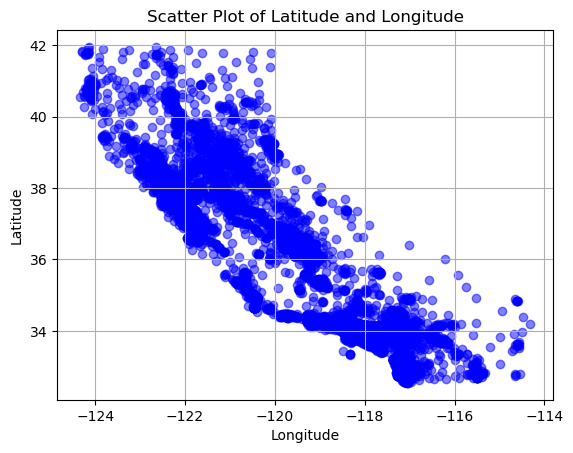

```python
plt.scatter(df['longitude'], df['latitude'], color='blue', alpha=0.5)
plt.title('Scatter Plot of Latitude and Longitude')
plt.xlabel('Longitude')
plt.ylabel('Latitude')
plt.grid(True)
plt.show()
```

Before our clustering, we will create a scatter plot to visualize the data according to the latitude and longitude coordinates. This allows us to gain insights into the geographical distribution before using K-Means to cluster the points based on the specified factors.

# Data Cleaning

As seen from the prior analysis of the dataset's statistical summary, it looks like there are missing observations that need to be addressed. In this data cleaning process, we can utilize 'df.isnull().sum()' to find which column the missing values are from. After that, we will implement '.dropna()' to remove these observations. We decided that removing the rows with missing observations is the best practice for this instance in order to ensure data integrity. Lastly, we will double-check to make sure there are no longer any missing values.

```python
df.isnull().sum()
```

```
longitude               0
latitude                0
housing_median_age      0
total_rooms             0
total_bedrooms        207
population              0
households              0
median_income           0
median_house_value      0
ocean_proximity         0
dtype: int64
```

There are 207 missing values in the 'total_bedrooms' column.

```python
df.dropna(inplace=True)
```

We have removed these values to ensure data integrity.

```python
df.isnull().sum()
```

```
longitude             0
latitude              0
housing_median_age    0
total_rooms           0
total_bedrooms        0
population            0
households            0
median_income         0
median_house_value    0
ocean_proximity       0
dtype: int64
```

Now, there are no missing values anymore, so the 'data cleaning portion' is complete.

# Clustering With Elbow Method Optimization

In this section, we will use the elbow method to determine the optimal number of clusters for K-means clustering based on longitude, latitude, and median income values. Rather than only clustering on geographic location, we want to identify clusters that consider both spatial and socioeconomic factors. We will plot the elbow plot to visualize the inertia (within-cluster sum of squares) against different numbers of clusters, revealing the point where the inertia starts to decrease at a slower rate, indicating the optimal cluster count. Then, we perform K-means clustering with the optimal number of clusters and visualize the resulting clusters on a scatter plot.

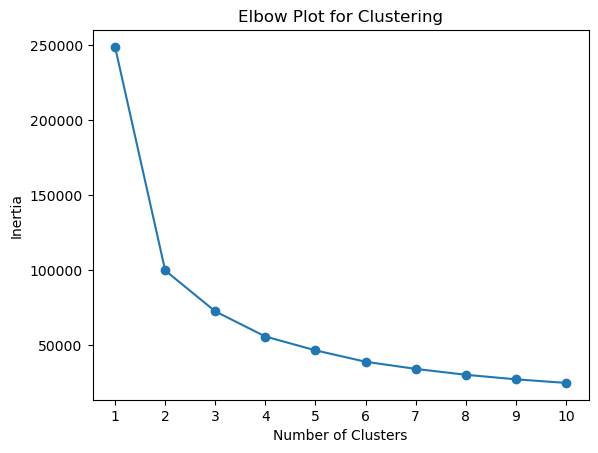

```python
X = df[['longitude', 'latitude', 'median_income']]

# Create Elbow Plot To Find Optimal Number Of Clusters
inertia = []
k_range = range(1, 11)
for i in k_range:
    kmeans = KMeans(n_clusters=i, random_state=42, n_init = 10)
    kmeans.fit(X)
    inertia.append(kmeans.inertia_)

# Plot
plt.plot(k_range, inertia, marker='o')
plt.title('Elbow Plot for Clustering')
plt.xlabel('Number of Clusters')
plt.ylabel('Inertia')
plt.xticks(k_range)
plt.show()
```

Analyzing this elbow plot, we see that the major declines in slope are at n=2 and n=3 clusters. We will focus on using 3 clusters because it strikes a balance between simplicity and an overly complex segmentation. Additionally, this will allow us to gain a meaningful interpretation on the housing and socioeconomic patterns of these different groups.

```python
X = df[['longitude', 'latitude', 'median_income']]

# Perform K-Means Clustering
kmeans = KMeans(n_clusters=3, random_state=42,n_init = 10)
kmeans.fit(X)
```

```
KMeans(n_clusters=3, n_init=10, random_state=42)
```

Here, we have used K-Means clustering to group data points based on their 'longitude', 'latitude', and 'median_income' features into three clusters. Initially, it extracts these features from our DataFrame. Then, it sets up a K-Means clustering model with three clusters and specified random state and initialization parameters. The K-Means algorithm is then applied to the extracted data, finding the optimal centroids and assigning each data point to the nearest centroid to assist in forming the three clusters. This process essentially divides the data into groups based on similarities in the given features.

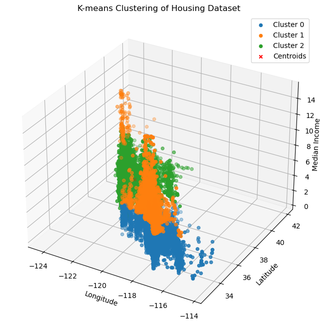

```python
from mpl_toolkits.mplot3d import Axes3D

# Add Cluster Labels To The DataFrame
df['cluster_label'] = kmeans.labels_

# 3-D Visualize
fig = plt.figure(figsize=(10, 8))
ax = fig.add_subplot(111, projection='3d')

for cluster_label in range(3):
    cluster_points = df[df['cluster_label'] == cluster_label]
    ax.scatter(cluster_points['longitude'], cluster_points['latitude'], cluster_points['median_income'], label=f'Cluster {cluster_label}')

ax.scatter(kmeans.cluster_centers_[:, 0], kmeans.cluster_centers_[:, 1], kmeans.cluster_centers_[:, 2], marker='x', color='red', label='Centroids')

ax.set_title('K-means Clustering of Housing Dataset')
ax.set_xlabel('Longitude')
ax.set_ylabel('Latitude')
ax.set_zlabel('Median Income', labelpad=-2)
ax.xaxis.set_ticks_position('lower')
ax.legend()
plt.show()
```

The visualization above shows the result of the K-Means clustering in three dimensions (latitude, longitude, median income). Each color is assigned to a different cluster that it represents, with the centroids being marked by a red X (but it is fairly hard to see here). This visualization allows for an understanding of how the data points have been divided after our unsupervised algorithm has been performed. After this, we may want to view the clusters solely based off the two geographical dimensions (latitude/longitude) to get a better view of the clusters and centroids themselves.

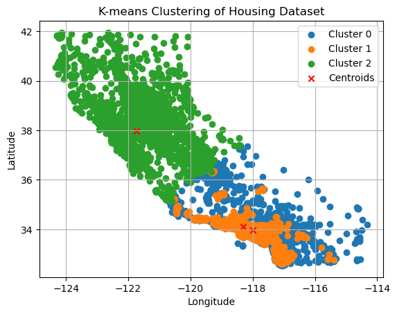

```python
df['cluster_label'] = kmeans.labels_

# 2-D Visualize
for cluster_label in range(3):
    cluster_points = df[df['cluster_label'] == cluster_label]
    plt.scatter(cluster_points['longitude'], cluster_points['latitude'], label=f'Cluster {cluster_label}')
plt.scatter(kmeans.cluster_centers_[:, 0], kmeans.cluster_centers_[:, 1], marker='x', color='red', label='Centroids')
plt.title('K-means Clustering of Housing Dataset')
plt.xlabel('Longitude')
plt.ylabel('Latitude')
plt.legend()
plt.grid(True)
plt.show()
```

Now, we are going to visualize the clusters based on two dimensions (longitude and latitude) to get a better view of the centroids and segmentation across the California landscape. After viewing these, we see that there are three clusters. The first cluster is in the southern end of California, but it seems to represent the areas that are more inland. Compared to that, the second cluster is also in the southern end, but it represents the areas on the coast of Southern to central California. Lastly, the third cluster represents the entirety of the Northern end of the state. By observing median income along with the geographical coordinates (longitude and latitude), we can effectively make observations about the higher/lower income areas as well as the location. We will keep in mind these locations further into our analysis as well.

```python
df.head()
```

|  | longitude | latitude | housing_median_age | total_rooms | total_bedrooms | population | households | median_income | median_house_value | ocean_proximity | cluster_label |
| --- | --- | --- | --- | --- | --- | --- | --- | --- | --- | --- | --- |
| 0 | -122.23 | 37.88 | 41.0 | 880.0 | 129.0 | 322.0 | 126.0 | 8.3252 | 452600.0 | NEAR BAY | 2 |
| 1 | -122.22 | 37.86 | 21.0 | 7099.0 | 1106.0 | 2401.0 | 1138.0 | 8.3014 | 358500.0 | NEAR BAY | 2 |
| 2 | -122.24 | 37.85 | 52.0 | 1467.0 | 190.0 | 496.0 | 177.0 | 7.2574 | 352100.0 | NEAR BAY | 2 |
| 3 | -122.25 | 37.85 | 52.0 | 1274.0 | 235.0 | 558.0 | 219.0 | 5.6431 | 341300.0 | NEAR BAY | 2 |
| 4 | -122.25 | 37.85 | 52.0 | 1627.0 | 280.0 | 565.0 | 259.0 | 3.8462 | 342200.0 | NEAR BAY | 2 |

Now, looking at 'df.head' again to view the DataFrame, we can see that an additional column has been added, entitled 'cluster_label'. This column value represents the cluster number that is given to this row.

# Post-Clustering Visualizations

In this post-clustering visualization section, boxplots are utilized to illustrate the distribution of median income and median housing age. Furthermore, a scatter plot is used to show median house price and median income, revealing a possible correlation with the two variables. Lastly, a stacked bar plot displays the percentage of ocean proximity for each cluster, offering an understanding of the distribution of areas such as coastal and inland within the clustered data. These visualizations aid in providing a comprehensive analysis of the clustered data.

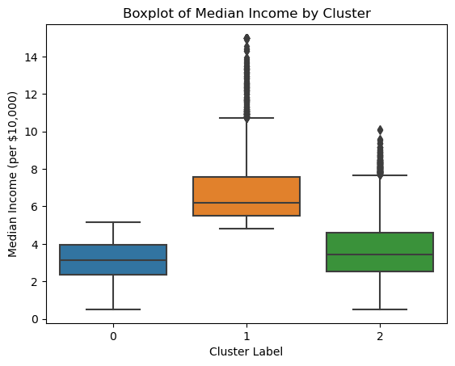

```python
sns.boxplot(x='cluster_label', y='median_income', data=df)
plt.title('Boxplot of Median Income by Cluster')
plt.xlabel('Cluster Label')
plt.ylabel('Median Income (per $10,000)')
plt.show()
```

Here, we have used Seaborn to generate three separate boxplots for each cluster label. The x-axis represents cluster labels, while the y-axis displays median income values (scaled per $10,000). As we examine these boxplots, we can see that cluster one has a significantly higher median income compared to clusters zero and two (with two and zero being extremely close in income). This disparity suggests varying socioeconomic profiles across geographical regions within California. If we look back at the two-dimensional graph, we see that the areas on the coast of Southern California have a significantly higher median income. This could suggest that coastal areas in Southern California tend to have higher-income residents compared to inland regions.

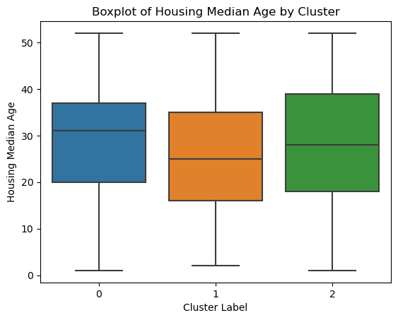

```python
sns.boxplot(x='cluster_label', y='housing_median_age', data=df)
plt.title('Boxplot of Housing Median Age by Cluster')
plt.xlabel('Cluster Label')
plt.ylabel('Housing Median Age')
plt.show()
```

Similarly to before, we have generated three separate boxplots for each cluster label. The x-axis represents the cluster labels, while the y-axis shows the median house age. Here, cluster one encapsulates the houses that tend to have the lower median age (with cluster two being the second newest and zero being the oldest). This visualization provides insights, allowing us to understand how the age of houses varies among the identified clusters. Additionally, it reveals that the clusters with the higher median income also have newer houses. By observing the median house age alongside the cluster labels, we can observe the age distribution patterns within each cluster, which can inform various decisions related to real estate investment and urban planning.

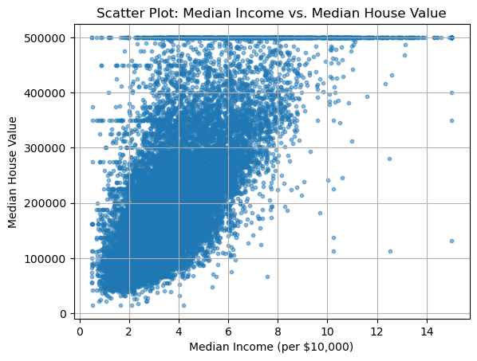

```python
plt.scatter(df['median_income'], df['median_house_value'], alpha=0.5, s=10)
plt.title('Scatter Plot: Median Income vs. Median House Value')
plt.xlabel('Median Income (per $10,000)')
plt.ylabel('Median House Value')
plt.grid(True)
plt.show()
```

Looking at this scatter plot showing the correlation between median income per $10,000 and median house value, there is a clear positive correlation displayed here. That means that as median income increases, median house value tends to increase as well. This relationship is fairly intuitive, as areas with higher median incomes typically have higher-priced housing markets due to increased demand and purchasing power. This insight can be valuable for various stakeholders, such as homebuyers, real estate investors, and policymakers, as it highlights the connection between income levels and housing prices in a given area. Additionally, understanding this correlation can aid in decision-making processes related to housing affordability, market analysis, and economic development strategies.

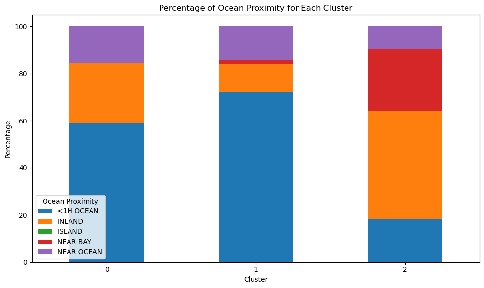

```python
# Calculate Percentage Of Ocean Proximity For Each Cluster
cluster_ocean_percentage = (df.groupby(['cluster_label', 'ocean_proximity']).size() / df.groupby('cluster_label').size()) * 100

# Plot
cluster_ocean_percentage.unstack().plot(kind='bar', stacked=True, figsize=(10, 6))
plt.title('Percentage of Ocean Proximity for Each Cluster')
plt.xlabel('Cluster')
plt.ylabel('Percentage')
plt.xticks(rotation=0)
plt.legend(title='Ocean Proximity')
plt.tight_layout()
plt.show()
```

Lastly, this code segments the data by cluster labels and ocean proximity categories to calculate the percentage distribution of ocean proximity within each cluster. Additionally, it generates a stacked bar chart, where the x-axis represents cluster labels, and the y-axis is the proportion of each ocean proximity category. By remembering our prior analysis, we can remember that cluster one had by far, the highest median income (and subsequently, median housing value) is represented by cluster one, which is overwhelmingly made up of houses that are <1H from the ocean. Additionally, it has a small percentage of houses that are inland, compared to the two other clusters. This highlights the influence of coastal proximity on housing market dynamics; it also aids in understanding the spatial patterns of ocean proximity within the identified clusters, which can be used to make informed decisions on urban planning / real estate.

# Conclusion

## **Implications and Actionable Insights:**

The insights from the K-means clustering analysis of the California housing market dataset offer valuable applications in the real world across various industries. For real estate investors and developers, understanding the geographical distribution and socioeconomic profiles of different clusters enables targeted investment strategies. By identifying areas with high potential for growth or properties that are undervalued, investors can optimize their allocations and maximize profit. Urban planners and policymakers can apply these insights to guide choices about things such as building roads, determining where different kinds of buildings should be located, and ensuring there's enough affordable housing available. This helps cities grow in a fair and sustainable way, making sure everyone has access to housing and that the environment around them is protected. Moreover, businesses in related industries, such as retail and services, can tailor their offerings and expansion plans based on the characteristics of each cluster, optimizing customer targeting. Overall, the actionable insights conveyed from this analysis provide an approach to navigating the several dynamics of the California housing market, which can be widely used to help make informed decisions.